# PekerisModeSolver

| **Model** | `UnderwaterAcoustics.PekerisModeSolver` |
| --- | --- |
| **Description** | Normal mode model for constant depth iso-velocity environments |
| **Language** | Julia |
| **Advantages** | Fast, differentiable (forward mode), multi-threaded |
| **Limitations** | Iso-velocity, pressure-release surface, fluid half-space seabed, no seabed absorption (no leaky modes) |
| **Differentiability** | `ForwardDiff` |

```
PekerisModeSolver(env; ngrid=0, nmodes=0)
```

A fast differentiable mode propagation model that only supports iso-velocity constant depth environments.

`ngrid` is the number of grid points to use for modal root finding for fluid bottom environments. If `ngrid` is too small, the mode solver may miss some modes. If `ngrid` is too large, the mode solver may take a long time to converge. The default value of `ngrid` of 0 will use a heuristic to automatically determine the number of grid points to use.

`nmodes` controls the maximum number of modes computed. Setting `nmodes` to 0 causes all propagating modes to be computed.

Implementation largely based on mathematical description in:

- M. B. Porter, “The KRAKEN normal mode program”, Technical report NRL/MR/5120-92-6920, Naval Research Laboratory, 1992 [(pdf)](https://apps.dtic.mil/sti/tr/pdf/ADA252409.pdf).

**Tip**

The theory of modal models is summarized in a brief note “On modal models”. It provides an overview of the key concepts and mathematical formulations, as implemented in this model.

While the `PekerisModeSolver` is range-independent by itself, it can be made range-dependent by using `AdiabaticExt` as shown in the example below.

## Examples

### Range-independent scenario

```julia
using UnderwaterAcoustics
using Plots

env = UnderwaterEnvironment(
  bathymetry = 5000,
  soundspeed = 1500,
  density = 1000,
  seabed = FluidBoundary(2000, 2000)
)
pm = PekerisModeSolver(env)

tx = AcousticSource(0, -500, 10)
rx = AcousticReceiver(200000, -2500)
modes = arrivals(pm, tx, rx)[1:7]      # first 7 modes
```

```
7 element Vector{ModeArrival}:
  mode 1: kᵣ = 0.041883 - 0.0im rad/m, v = 1499.84 m/s, vₚ = 1500.16 m/s
  mode 2: kᵣ = 0.04187 - 0.0im rad/m, v = 1499.36 m/s, vₚ = 1500.66 m/s
  mode 3: kᵣ = 0.041847 - 0.0im rad/m, v = 1498.56 m/s, vₚ = 1501.48 m/s
  mode 4: kᵣ = 0.041815 - 0.0im rad/m, v = 1497.45 m/s, vₚ = 1502.63 m/s
  mode 5: kᵣ = 0.041773 - 0.0im rad/m, v = 1496.01 m/s, vₚ = 1504.12 m/s
  mode 6: kᵣ = 0.041723 - 0.0im rad/m, v = 1494.24 m/s, vₚ = 1505.94 m/s
  mode 7: kᵣ = 0.041663 - 0.0im rad/m, v = 1492.15 m/s, vₚ = 1508.10 m/s
```

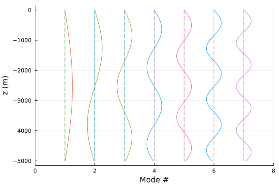

```julia
# plot the modes
plot(modes)
```

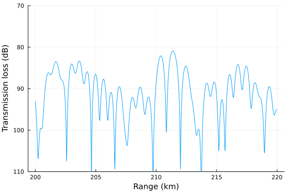

```julia
rxs = AcousticReceiverGrid2D(200000:10:220000, -2500)
x = transmission_loss(pm, tx, rxs)

plot(200:0.01:220, x; ylims=(70,110), yflip=true, legend=false,
  xlabel="Range (km)", ylabel="Transmission loss (dB)")
```

### Range-dependent scenario

```julia
using UnderwaterAcoustics
using Plots

env = UnderwaterEnvironment(
  bathymetry = SampledField([200, 150, 200]; x=[0, 2000, 5000]),
  soundspeed = 1500,
  density = 1000,
  seabed = FluidBoundary(2000, 2000)
)

# use an adiabatic extension to the PekerisModeSolver for range-dependence
pm = AdiabaticExt(PekerisModeSolver, env)

tx = AcousticSource(0, -50, 250)
rx = AcousticReceiver(7000, -25)
modes = arrivals(pm, tx, rx)[1:7]      # first 7 modes
```

```
7 element Vector{ModeArrival}:
  mode 1: kᵣ = 1.047083 - 0.0im rad/m, v = 1499.80 m/s, vₚ = 1500.16 m/s
  mode 2: kᵣ = 1.04674 - 0.0im rad/m, v = 1499.22 m/s, vₚ = 1500.66 m/s
  mode 3: kᵣ = 1.046167 - 0.0im rad/m, v = 1498.24 m/s, vₚ = 1501.48 m/s
  mode 4: kᵣ = 1.045364 - 0.0im rad/m, v = 1496.86 m/s, vₚ = 1502.63 m/s
  mode 5: kᵣ = 1.044331 - 0.0im rad/m, v = 1495.09 m/s, vₚ = 1504.12 m/s
  mode 6: kᵣ = 1.043066 - 0.0im rad/m, v = 1492.91 m/s, vₚ = 1505.94 m/s
  mode 7: kᵣ = 1.04157 - 0.0im rad/m, v = 1490.34 m/s, vₚ = 1508.10 m/s
```

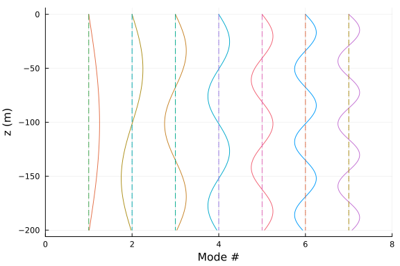

```julia
# plot the modes
plot(modes)
```

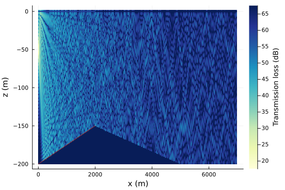

```julia
rxs = AcousticReceiverGrid2D(10:10:7000, -200:1)
x = transmission_loss(pm, tx, rxs)

plot(rxs, x; crange=50)
plot!(env)
```

We can also estimate a bandlimited impulse response from the propagation model:

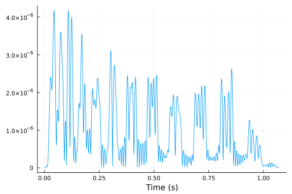

```julia
plot(impulse_response(pm, tx, rx, 8000; fmin=200, fmax=300))
```

## Notes

- Differentiability currently works only with `ForwardDiff`, and excludes `impulse_response()`.